# From LATE to GREAT

Model-based extrapolation of local average treatment effects

Brice Green

2020-10-08

# Abstract

Causal estimates are critical for understanding policy interventions, but without assuming that treatment effects are constant it is difficult to know how to extrapolate those estimates to new populations. This paper proposes a framework borrowed from the survey literature for directly measuring how treatment effects vary across the population, and demonstrates how to use the model to extrapolate to new populations.

# Introduction

Our hope as scientists and policy makers is to perform inferences that generalize beyond the immediate scope of our experiments. Beyond simply the scientific enterprise, the ability to extrapolate from experiments to populations at large is key to effective policy decisions. However, it is often implausible to assume all people respond the same way to the same treatment, and when we relax that assumption, we are left with an estimate that is obnoxiously glued to our specific sample.

One great advantage of modern measurement is that we have rich information about the different subjects in our studies, and even use that information to adjust our estimates for factors that we could not adequately randomize on or to accommodate different baselines from which we are measuring treatment responses. However, we can do more than merely adjust estimates of the average, but also directly estimate how treatment effects vary across the population.

In this context, I propose a four-step plan from moving from LATE to Great (no acronym as of now):

1. Bin
2. Model
3. Project
4. Maximize

First, we bin observations into groups, based on their observable characteristics. When variables are continuous, this involves discretizing the variable into bins. Second we create a principled model that describes how the cells relate to one another. Third, we take our estimates from our first population and project them onto a new one based on know or expected weights for the new population. The fourth step, should you need it, uses the projections of the model in combination with a utility (or loss) function that represents policy trade-offs to maximize (minimize) expected utility for a new policy roll-out.

The major challenge of this approach is that it runs head-long into the curse of dimensionality. The modeler faces a trade-off between the number of parameters to estimate and the number of observations to collect. Given a fixed set of observations $N$, the number of sub-groups grows exponentially along each dimension measured, representing (at minimum) three parameters to be estimated per group: the baseline response, the treated response, and the variance. The key insight here is that we have information about how these parameters relate to one another, which allows us to effectively identify high-dimensional, non-linear interaction effects.

In the paper I am going to be dealing with the estimation of a treatment effect given an experiment with non-compliance, presuming that the analyst does not know a priori that treatment effects are constant. The treatment effects, in this case, are a kind of latent response surface, varying across characteristics that are either observed or not, corresponding to the expected outcome for an individual receiving treatment. I will work with binary treatments and continuous outcomes in an instrumental variables setting, though the results generalize easily to an experimental context with full compliance.

It is less obvious how this would generalize to a regression discontinuity design or similar inference methods.

Given subjects indexed by $i$, a binary treatment $d \in \{0,1\}$, a continuous or binary instrumental variable $Z$, and an outcome $Y$, let $Y_i(1)$ denote the outcome for individual $i$ had they gotten the treatment and $Y_i(0)$ indicate the outcome had they not received the treatment.

$$\tau = E(Y_i(1)) - E(Y_i(0))$$

In general without full compliance,

$$\tau \neq E(Y_i(1) - Y_i(0)).$$

In economics, we commonly expect this to be violated, as people making choices tend to choose things which they believe will bring them outcomes that they prefer, inducing a strong correlation between outcomes and treated status. To solve this, we introduce an instrumental variable $Z$, such that $d$ is a non-trivial function of $Z$.

Following the standard literature, I call “compliers” those in the sample who would have taken the treatment, given a shock from $Z$, but would not have otherwise. This is in comparison to “always-takers” who would take the treatment regardless of $Z$, and “never-takers” are those who can never be induced by $Z$ to take up treatment. Assuming non-interference ($d_i$ depends on $z_i$ and not $z_{j \neq i}$) excludability (that outcomes do not depend on $z_i$ except via $d_i$, and monotonicity (an increase in $Z$ never leads to a *decrease* in the probability of treatment uptake).

Furthermore, I presume that everything of interest has been measured and incorporated into the model, or that given observable characteristics $X$, we expect treatment effects $\tau$ to be a function of $X$, and not variables we have not measured.

In the machine learning literature it is common to construct estimators that induce sparsity so as to remove variables that are not highly predictive. However, in this context sparsity may not be desirable; typically we think of treatment effects as being smooth, and simply setting the marginal movement of a bin around a central value to zero constructs a jagged set of point estimates. In addition, we are often interested in uncertainty around treatment effects, and quantifying that estimation uncertainty is non-trivial for penalized estimators. Finally, depending on the size of the grid, we may not expect the marginal effect of a given bin to be large, but we may expect them to be non-zero. It may actually be preferable to estimate a series of small, smoother changes across a large number of points in a grid, rather than to construct a grid that is wider or smaller depending on point predictions.

I propose a different type of model that relates estimates across cells through a latent likelihood equation. In other words, given some grid-wise sampling density

$$Y_i \sim f(\tau_i, \theta),$$

I construct a model that describes the variation of the treatment effects

$$\tau_i \sim g(\theta),$$
and finally I put a prior on the hyper-parameters $\theta$ that penalize the complexity of the model to prevent overfitting. So, finally,

$$\theta \sim \Pi(\theta).$$

This is commonly referred to a “multilevel” or “hierarchical” model, referring to its three-level structure, though it can be collapsed into a single likelihood. The structure itself is quite flexible, as the likelihood function $f$ can correspond to whatever the appropriate likelihood is for the observed data. Typically $g$ is parameterized by a normal distribution, owing to the central limit theorem, with a mean linearized out and variation around that mean parameterized depending on the specific application.

The goal of $g$ and $\Pi$ in this structure is not to provide strong information about the specific realization we expect (say, incorporating information from a previous study about the treatment effect itself), but instead to describe a class of models that support the local regularities we believe structurally exist in the data generating process. All the while, it would be unwarranted to construct $g$ in such as way as to make believable parameter values unlikely or rule out possibilities altogether.

The trick to why this model works so effectively is that it no longer forces the various cells to be estimated independently of each other, and in the limit can accommodate both complete dependence and complete independence between cell-wise means. As the number of parameters to be estimated approach or exceed the number of observations we have available, it can limit the search for the appropriate model to a reasonable class.

For continuous and ordinal variables, I treat the covariate lattice as a Gaussian Markov Random Field. In two dimensions, call $\theta_{i,j}$ a parameter in a cell along an even grid of binned covariates. Its neighbors are then $\Gamma = \{\theta_{i-1, j}$, $\theta_{i+1, j}$, $\theta_{i, j-1}\}$, and $\theta_{i, j+1}$. The simplifying assumption of a Gaussian Markov Random Field (relative to a general random field) is that all of the information relevant to estimating cell $\theta_{i,j}$ is incorporated in its neighboring estimates. In other words, for some parameter

$$P(\theta_{i,j} | \theta_{i,-j}; \theta_{-i,j}) = P(\theta_{i,j} | \Gamma)$$

We can then approximate this relationship with a linear basis function, sometimes called a Conditional Autoregressive Process, where

$$\theta_{i,j} \sim Normal(\alpha \Gamma, \Sigma)$$
though typically this is estimated via the precision matrix, $Q = \Sigma^{-1}$ for computational efficiency.

For unordered variables, we have no concept of “adjacency”, so I propose a nested normal prior, where

$$\theta_{i,j} \sim Normal(\theta, \sigma),$$

a common model in education research (Rubin 1981), meta-analysis (Meager 2019), and highly related models political science (Ghitza and Gelman 2013).

Rubin, Donald B. 1981. “Estimation in Parallel Randomized Experiments.” *Journal of Educational Statistics* 6 (4): 377–401.

Meager, Rachael. 2019. “Understanding the Average Impact of Microcredit Expansions: A Bayesian Hierarchical Analysis of Seven Randomized Experiments.” *American Economic Journal: Applied Economics* 11 (1): 57–91.

Ghitza, Yair, and Andrew Gelman. 2013. “Deep Interactions with Mrp: Election Turnout and Voting Patterns Among Small Electoral Subgroups.” *American Journal of Political Science* 57 (3): 762–76.

While at first these parametric assumptions appear restrictive, they contain many important cases. For example, $\alpha = 0$ corresponds to complete independence between all cells and $\alpha = 1$ corresponds to constant treatment effects. For unordered variables, as $\sigma \to 0$, we end up with constant treatment effects, and as $\sigma \to \infty$ we end up with cell-wise independent means, just as we would with stratified IV.

Using a model that fully describes the data generating process also facilitates extrapolation not just of treatment effects, but any parameter of interest. For example, if we believed there to be heteroskedasticity, in principle we could estimate the scale of the residuals as a function that varied along with characteristics.

But more importantly, in making explicit our assumptions about the world the policy decision of the analyst is highly simplified, and what was previously an opaque set of judgements can now be discussed. If we estimate the model via a “fully Bayesian” approach, where we generate the full posterior distribution for all parameters, the projected version of those estimates represents the analysts’ best guess at the state space in their new location. Presuming they have convex policy preferences that can be represented with some form of von Neumann-Morgenstern utility function, the optimal policy is simply the one that maximizes the expected utility of the policy rollout, which (given a utility function and a set of posterior draws) is trivial to estimate.

Perhaps the best argument for the model is that the empirical performance is striking, having a lower mean squared error and higher $R^2$ than 2-stage-least-squares estimation even in cases with few categories. The bias of the method reduces with finer grids without a comparable reduction in variance, generating good representations even when the number of cells exceeds the number of observations.

In addition to the paper, I have made estimation software available at github.com/be-green/late-to-great/, with efficient implementations of the models coded in Stan, a probabilistic programming language that facilitates maximum likelihood, fully Bayesian Markov Chain Monte Carlo, and Maximum a Posteriori estimation via variational Bayesian methods (Carpenter et al. 2017).

Carpenter, Bob, Andrew Gelman, Matthew D Hoffman, Daniel Lee, Ben Goodrich, Michael Betancourt, Marcus Brubaker, Jiqiang Guo, Peter Li, and Allen Riddell. 2017. “Stan: A Probabilistic Programming Language.” *Journal of Statistical Software* 76 (1).

# Background

There is a long history of instrumental variables being used to address a history of experimental and psuedo-experimental conditions without full compliance, dating back to Wright (1928), and growing immensely in popularity since Angrist, Imbens, and Rubin (1996). There is simply so much work evaluating and understanding instrumental variables approaches and I am going to limit this discussion to a specific context: we know that necessary assumptions are satisfied (e.g. exclusion, monotonicity, etc.), and we are in the just-identified case with one instrument and one endogenous variable.

Wright, Philip G. 1928. *Tariff on Animal and Vegetable Oils*. Macmillan Company, New York.

Angrist, Joshua D, Guido W Imbens, and Donald B Rubin. 1996. “Identification of Causal Effects Using Instrumental Variables.” *Journal of the American Statistical Association* 91 (434): 444–55.

There is a substantial amount of literature in more recent years focused on extrapolating estimates from one population to a new population, and analyzing to what extent local average treatment effects are portable. In the economics literature, there is a substantial amount of attention on estimating to what extent a LATE approximates an ATE, and identifying to what extent researchers should be concerned with variation in treatment effects across different parts of the population.

There are several papers in this vein, which largely use the observable characteristics of the various sub-groups in the analysis: the always takers, never takers, and compliers. Perhaps most closely to this paper, Abadie (2003) argues for using estimators that create an approximation to a full treatment effect function that varies with observable characteristics. Kowalski (2016) proposes extrapolating to new situations or programs by examining the marginal treatment effect, or the treatment effect for the person who is marginally entering treatment given an instrument.

Abadie, Alberto. 2003. “Semiparametric Instrumental Variable Estimation of Treatment Response Models.” *Journal of Econometrics* 113 (2): 231–63.

Kowalski, Amanda E. 2016. “Doing More When You’re Running Late: Applying Marginal Treatment Effect Methods to Examine Treatment Effect Heterogeneity in Experiments.” National Bureau of Economic Research.

However, most of these papers are concerned with adjusting for differences between the population which takes up the treatment from the overall group (extrapolating the local average treatment effect to the average treatment effect). While the model presented in this paper can help address the same concerns as the previous literature, it can also be used to extrapolate effectively from one experimental context to a new, quite distant, population, which might not have the same structure for take-up of the treatment at all.

The problem of projecting high-dimensional and non-linear interaction effects onto new populations is a long-standing problem in the survey literature, especially in political science, where researchers are often interested in using polls from one state to forecast outcomes in a different state or the whole country (Wang et al. 2015), or to do inference on sets of complicated interaction effects for different sub-populations (Ghitza and Gelman 2013). Traditionally, the approach is to take a non-representative polling population, divide those populations into several sub-categories, and re-weight the outcomes to reflect the new population total (this goes back at least as far as (Deming and Stephan 1940)).

Wang, Wei, David Rothschild, Sharad Goel, and Andrew Gelman. 2015. “Forecasting Elections with Non-Representative Polls.” *International Journal of Forecasting* 31 (3): 980–91.

Ghitza, Yair, and Andrew Gelman. 2013. “Deep Interactions with Mrp: Election Turnout and Voting Patterns Among Small Electoral Subgroups.” *American Journal of Political Science* 57 (3): 762–76.

Deming, W Edwards, and Frederick F Stephan. 1940. “On a Least Squares Adjustment of a Sampled Frequency Table When the Expected Marginal Totals Are Known.” *The Annals of Mathematical Statistics* 11 (4): 427–44.

However, this approach suffers from the curse of dimensionality: while it is desirable to have a finer grid along the characteristics you are estimating, the number of estimation cells grows geometrically with each additional characteristic you include. Gelman and Little (1997) demonstrate the efficacy of multilevel regression modeling in capturing that variation, providing a structure that can both capture complete independence between cells, while also allowing for constant responses across all cells along similar characteristics. There is a substantial amount of recent work on this problem, notably Gao et al. (2020), who incorporate structural information to the modeling of variation of responses along observed characteristics, and Kennedy and Gelman (2019), who applies a similar approach to an experimental context.

Gelman, Andrew, and Thomas C Little. 1997. “Poststratification into Many Categories Using Hierarchical Logistic Regression.”

Gao, Yuxiang, Lauren Kennedy, Daniel Simpson, Andrew Gelman, and others. 2020. “Improving Multilevel Regression and Poststratification with Structured Priors.” *Bayesian Analysis*.

Kennedy, Lauren, and Andrew Gelman. 2019. “Know Your Population and Know Your Model: Using Model-Based Regression and Poststratification to Generalize Findings Beyond the Observed Sample.” *arXiv Preprint arXiv:1906.11323*.

Thus far in the causal inference literature, the approach to measuring conditional average treatment effects (separate treatment effects along some partition of the space of measured variables) has been focused on efficiently partitioning the space to capture the parts of the population that have substantially different treatment effects. With traditional estimators that forgo using any prior information about the structure of the model, this helps to balance between the expected variance of the estimator and how well approximated the treatment effect is by an average. Examples include an approach using a single tree to partition the covariate space (Athey and Imbens 2016), and averages across lots of trees (average of effects across reasonable partitions) (Hill 2011; Wager and Athey 2018).

Athey, Susan, and Guido Imbens. 2016. “Recursive Partitioning for Heterogeneous Causal Effects.” *Proceedings of the National Academy of Sciences* 113 (27): 7353–60.

Hill, Jennifer L. 2011. “Bayesian Nonparametric Modeling for Causal Inference.” *Journal of Computational and Graphical Statistics* 20 (1): 217–40.

Wager, Stefan, and Susan Athey. 2018. “Estimation and Inference of Heterogeneous Treatment Effects Using Random Forests.” *Journal of the American Statistical Association* 113 (523): 1228–42.

In principle, the multilevel model proposed in this paper could be used to complement any method used to partition the covariate space. However, it is easiest to compare and simulate along an even grid of covariates, because in other cases it requires adjustments to the prior scale. However, the method is widely used in spatial statistics, even in settings with non-Euclidean distance metrics, using finite-element approximation techniques borrowed from the engineering literature (Lindgren, Rue, and Lindström 2011).

Lindgren, Finn, Håvard Rue, and Johan Lindström. 2011. “An Explicit Link Between Gaussian Fields and Gaussian Markov Random Fields: The Stochastic Partial Differential Equation Approach.” *Journal of the Royal Statistical Society: Series B (Statistical Methodology)* 73 (4): 423–98.

# The approach

Given observable characteristics about our population, I propose directly measuring the how local average treatment effects vary across those characteristics. This is to say, given a continuous covariate like income or age, the analyst would break that variable into a series of even bins, measuring a LATE for those who fall in that bucket. Discrete or ordinal variables are already in buckets, so they are already how we want them. Under normal assumptions, the LATE can only identify an effect for the population of “compliers,” e.g. those who are moved into the treatment by the intervention, so this is the treatment effect we will estimate here. Thus, presuming that we have a treatment effect $\tau$ which is a smooth, integrable function of observable characteristics $X$

$$\tau = f(X),$$

we take some $\epsilon$ and calculate the average $\tau$ within that bucket using a normal means (say, a randomized trial, instrumental variables, what have you). Presume that $X$ is a random variable with support over the region being sampled with density $g(x)$ over the region being sampled. Taking the one-dimensional case for now, as the number people in this region of the parameter space approaches $\infty$,

$$\tau_\epsilon = \int_{x-\epsilon}^{x + \epsilon}f(x)g(x) dx.$$
In the limit, as $\epsilon \to 0$, $\tau_\epsilon \to \tau$.

The treatment effect measured in that cell is an interaction effect, with the estimated mean used to approximate the local behavior of the unobserved treatment effect function. This is essentially a “step-wise” approximation, with the level of each step being used to proxy for the local treatment effect of that subgroup (or, equivalently, the average treatment effect + the interaction term for the local subgroup and the treatment effect). However, this treatment effect function is a mapping from a possibly high-dimensional surface to some type of outcome variable. This makes traditional estimation approaches complicated, since we are always in a situation where the number of measurements of interest is large than the number of observations.

For example, suppose we measured a population of 10,000 individuals along a number of dimensions, like income, family size, and years of education. In a setting with a strong instrumental variable (where there is a well-measured, non-zero relationship between the instrument and the treatment uptake), we might be interested in understanding how treatment effects varied across all of those dimensions. There are a two ways to tackle this problem in the economics literature: measure the interaction effects via linear regression or stratify people into subgroups and run 2-stage-least-squares by subgroup.

The first case is probably the easiest to follow, with the interaction effect corresponding to the first-order Taylor expansion of the treatment effect function around the average level of the covariates of interest. Depending on the distribution of the covariates and the underlying function, this could be a highly effective strategy for estimating varying treatment effects. If we wanted to include all of the interaction effects (even with only three covariates), we would be running a regression with 10 control variables, a number which grows combinatorically with each additional variable of interest. The subgroups of interest are often poorly identified, with some sub-categories having lots of observations, and some having few. In addition, if there are non-linear effects, this first-order approximation of the effect may be a bad one, especially in parts of the covariate space far away from the average, and small errors in the slope estimate in the well-identified part of the population may create large errors in subpopulations far away from the mean, even if the effects are linear. This problem is especially salient when trying to extrapolate to new populations, since the local approximation measured in the original population may center around a completely different part of the covariate space than the new population.

The second case is more similar to the approach I am proposing, but runs head-long into the curse of dimensionality. The partition estimates a step-function approximation of the treatment effects, but depending on the variance of the treatment effect within that part of the partition, even a well-identified mean may be a poor approximation of the underlying function. However, we must trade off against the shrinking power of traditional estimators as the sample size grows smaller and smaller in each group.

Once again, taking the three covariates case, let us imagine that $\tau = \beta X^2$, where $X$ is a three-by-N matrix of covariates. Suppose that we observe covariates $X$ each uniformly distributed between -10 and 10, and have $N$ of 1000. It seems fairly common in economist papers to split groups into “high, medium, and low,” and so let us imagine we just do this. We, again, are interested in all of the interaction effects. That gives us an average of 37 people in each sub-group! While that may give us enough power to detect a large effect, it becomes clear that adding even one or two more groups ends up with an unidentified model and potentially infinite variance of our estimator.

Presuming (perhaps incorrectly) that we are even comfortable with $E(N_j) \approx 37$ for group j, there is yet a further tradeoff. Suppose we knew the precise treatment effects in each subgroup, and they were given to us on high. The mean squared error of using that mean as a point prediction over any interval $[a, b]$ in one dimension is given by

$$\int_a^b \left(f(x) - \dfrac{1}{b-a} \int_a^b f(x) \right)^2 dx$$

So if $F(x) = \int f(x) dx$, this becomes

$$\begin{aligned}
MSE(\mu_j) &= \int_a^b \left(f(x) - \dfrac{F(b) - F(a)}{b-a}\right)^2 dx \\
&= \dfrac{F(x)}{3}\left(f(x) - \dfrac{F(b) - F(a)}{b-a}\right)^3 \Big|_a^b \\
&= \dfrac{F(b)}{3}\left(f(b) - \dfrac{F(b) - F(a)}{b-a}\right)^3 - \dfrac{F(a)}{3}\left(f(a) - \dfrac{F(b) - F(a)}{b-a}\right)^3
\end{aligned}$$

and in multiple dimensions we just expand the formula. In the case of $f(X) = X^2$, we can just compute this value. Across one dimension of “medium” bucket, if the treatment effect is given by the function $x^2$, the *known* mean has a mean-squared-error of 7.2.

Suppose $b = c + \epsilon$, and $a = c - \epsilon$ for some $\epsilon > 0$. When choosing the number of subgroups to estimate, we are interested in choosing $\epsilon$ to minimize the variance of the estimator vs. the variance of mean as the approximation of the function. Fix c. Then the squared error of the approximation is given by

$$\begin{aligned}
MSE(\mu_j(\epsilon)) = & \dfrac{F(c + \epsilon)}{3}\left(f(c + \epsilon) - \dfrac{F(c + \epsilon) - F(c - \epsilon)}{2\epsilon}\right)^3 \\ &- \dfrac{F(c - \epsilon)}{3}\left(f(c - \epsilon) - \dfrac{F(c + \epsilon) - F(c - \epsilon)}{2\epsilon}\right)^3
\end{aligned}$$

Clearly this shrinks with $\epsilon$, but on the other hand the variance of the estimator approaches $\infty$ given $N < \infty$ and $\epsilon \to 0$. The specific, optimal bins to pick will depend on the slope and curvature of the function. However, since the number of groups grows exponentially with dimension on an even grid, we consistently find ourselves on the edge of this trade-off. This is to say that if we expect any kind of variation in each direction of measurement, we hit the limits of our estimator before we have the approximation we want.

Next I will introduce an estimator which is well-identified, even in the case where we have more bins than observations, by incorporating known information about the treatment function. Suppose the treatment function is smooth. Then we have some information about the local behavior of the function; if two bins are adjacent, they are more likely to be close than if they had been farther away. We can encode this information with an intrinsic conditional autoregressive model, which incorporates the estimates around a given cell in the form of a prior distribution.

We can represent a lattice as a series of neighbor relationships. Let each point in the center of a bin be a node on a graph or lattice. The clique is the set of adjacent points on the graph along each dimension. As a simplifying assumption, I am proposing to only include information about immediate neighbors. In other words for a set of parameters $\phi$ in cell $i$ (perhaps the baseline response and treatment effect) with neighboring cells $j$,

the effectiveness of this assumption is likely application specific (e.g. to incorporate non-local information, it might be good to include more distant relationships through a Gaussian process prior, see, for example Banerjee et al. (2008)).

Banerjee, Sudipto, Alan E Gelfand, Andrew O Finley, and Huiyan Sang. 2008. “Gaussian Predictive Process Models for Large Spatial Data Sets.” *Journal of the Royal Statistical Society: Series B (Statistical Methodology)* 70 (4): 825–48.

$$p(\phi_i | \phi_{j\neq i}, \phi_{-j}) = p(\phi_i | \phi_{j\neq i})$$

This models the process over which parameter values evolve along the covariate lattice as a Markov Random Field, meaning that it only depends on the states immediately proceeding this. These models have a substantial literature, dating back to Besag (1974), who motivates the approach for areal data as being equivalent to a global structure for the variation across a lattice via the Hammersley-Clifford theorem. Previous applications are most common in spatial models, where areal representations of distance encode neighbor relationships, and image processing, where pixels have a similar structure.

Besag, Julian. 1974. “Spatial Interaction and the Statistical Analysis of Lattice Systems.” *Journal of the Royal Statistical Society: Series B (Methodological)* 36 (2): 192–225.

Owing to the central limit theorem, the conditional distribution is modeled as a Gaussian density, with
$$p(\phi_i | \phi_{j\neq i}, \phi_{-j}) = N(\alpha \Sigma_{i\sim j} w_{i,j}\phi_j, q_i^{-1})$$

where $q^{-1}$ is the precision of the variance of cell $i$, $w_{i,j}$ represents the distance between $j$ and $i$, $i \sim j$ refers to the members of the clique of $i$’s neighbors, and $\alpha$ is the degree of spatial dependence. Because $\alpha$ is an estimated coefficient, these are often called “exact” CAR models.

A common variant, which allows for non-stationary variation around a central value, is called the Intrinsic Conditional Auto-Regressive Model (ICAR), where $\alpha$ is set to 1. Distance is arbitrary when working with scaled covariates on an evenly spaced lattice, and unobserved for ordinal covariates, so I make the simplifying assumption that the weights matrix is a set of binary indicators representing neighbor relationships. As a consequence of both of these assumptions, the expression becomes

$$p(\phi_i | \phi_{j\neq i}, \phi_{-j}, q_i^{-1}) = N(\dfrac{\Sigma_{i\sim j}\phi_i}{d_{i,i}}, \dfrac{1}{d_{i,i}q_i})$$
with the certainty about my prior guess on $\phi_i$ growing the more neighbor relationships I have, and the expectation being an average of the neighboring estimates. I chose to model the precision as a white noise process, with $q_i = 1$, which may or may not be appropriate depending on the application. However, when working with scaled outcome variables and not too many buckets, it helps to encode structural information we have about the treatment effects. In this case, it corresponds to the idea that without evidence we should view a movement away from the average of neighboring estimates to be within roughly one standard deviation of the outcome. When using too many buckets (e.g. a nearly continuous approximation) this type of prior may be too weak, and when using unscaled outcomes it may be too strong.

This prior is not, itself, a proper density, as it is invariant to any added constant. As a consequence, I estimate the mean of each parameter separately from the variation around it, and constrain variation around the mean to sum to zero. For details of the code and efficiently implementing this algorithm, refer to Morris et al. (2019).

Morris, Mitzi, Katherine Wheeler-Martin, Dan Simpson, Stephen J Mooney, Andrew Gelman, and Charles DiMaggio. 2019. “Bayesian Hierarchical Spatial Models: Implementing the Besag York Mollié Model in Stan.” *Spatial and Spatio-Temporal Epidemiology* 31: 100301.

This prior distribution acts as a way to augment the information available in each cell as the dimension of the aggregate estimate expands beyond what would otherwise be possible. It does so by providing a linear basis function that interpolates across cells with no information. To see this, consider a 1-dimensional example. The prior density of cell $i$ will simply be the average of the estimates of its neighbors, a set of lines drawn between both estimates which is weighted by the associated uncertainty on either side. This interpolation strategy is why this helps to include prior, structural information about the treatment effect being a smooth function.

The other advantage this approach is that it encodes the typical information structures used to model treatment effects as special cases. Should the information we observe push us away from a constant treatment effects assumption and towards infinite variance, we can recover the independent cell-wise model. On the other hand, if the constant treatment effects assumption proves to be correct, we can recover a model which pools the sample together. Since both are special cases, this prior information allows us (in a finite sample) to sit somewhere in the middle between completely un-pooled estimation and completely pooled estimation. The extent to which we share information across cells is driven by the model, which encodes structural ex-ante knowledge about the experiment.

As a consequence of this additional information, we can escape the potential trade-off between representing a high dimensional and non-linear function via a mean function and the infinite variance of the least squares estimator as the number of groups get large. When we are missing a group entirely, we interpolate between the surrounding cells, increasing the corresponding uncertainty about our parameter by $\dfrac{1}{d_i}$.

# Computational Evidence

To demonstrate the efficacy of the model relative to current approaches, I ran several hundred simulations from both linear and non-linear functions ranging from one to five dimensions. The model which uses the Gaussian Markov Random Field (GMRF) prior model on the structure of the covariates has indistinguishable bias and lower variance even in small dimensions and few groups. The advantage of the approach becomes clear as the number of groups and dimensions becomes large: often there are few observations in a group, and the variance of the least squares estimator grows vastly. By contrast, the GMRF model actually *improves* in terms of mean-squared-error and $R^2$ as the number of groups gets large because it is able to incorporate information across cells being estimated. Importantly for policy, it is also able to interpolate for cells which see no data at all, using the neighboring cells to make predictions about the missing group.

Treatment uptake for the theoretical consumers is a function of their privately known true treatment effect. The top 10% of all outcomes are “always-takers” in all cases. Both models recover the LATE via 2-stage-least squares, with random assignment of treatment via a strong instrument. The difference between them is only the prior distribution on the cells in the second stage regression. Both identify the causal effect using first stage predictions and uncertainties from OLS. Both regular OLS and the Bayesian model have the same causal identification conditions, since they are both instrumental variables designs. To simplify this aspect of the simulations, I am using a strong, binary instrument, a binary treatment, and continuous outcomes. These could all be relaxed in principle; the simplicity of the design is meant to allow the performance of the two estimators under the high-dimensional conditions to shine through.

The Bayesian model is fitted in Stan, a probabilistic programming language designed to facilitate inference of custom models (Carpenter et al. 2017). Stan is a flexible modeling language which leverages automatic differentiation and an adaptive variant of Hamiltonian Monte Carlo to efficiently sample from posterior distributions (Hoffman and Gelman 2014).

Carpenter, Bob, Andrew Gelman, Matthew D Hoffman, Daniel Lee, Ben Goodrich, Michael Betancourt, Marcus Brubaker, Jiqiang Guo, Peter Li, and Allen Riddell. 2017. “Stan: A Probabilistic Programming Language.” *Journal of Statistical Software* 76 (1).

Hoffman, Matthew D, and Andrew Gelman. 2014. “The No-U-Turn Sampler: Adaptively Setting Path Lengths in Hamiltonian Monte Carlo.” *J. Mach. Learn. Res.* 15 (1): 1593–1623.

For the purposes of comparing the two methods, I am using point predictions from OLS vs. the mean of the posterior of the Bayesian model fit. In all cases, I used 1,000 individuals who were drawn into the study.

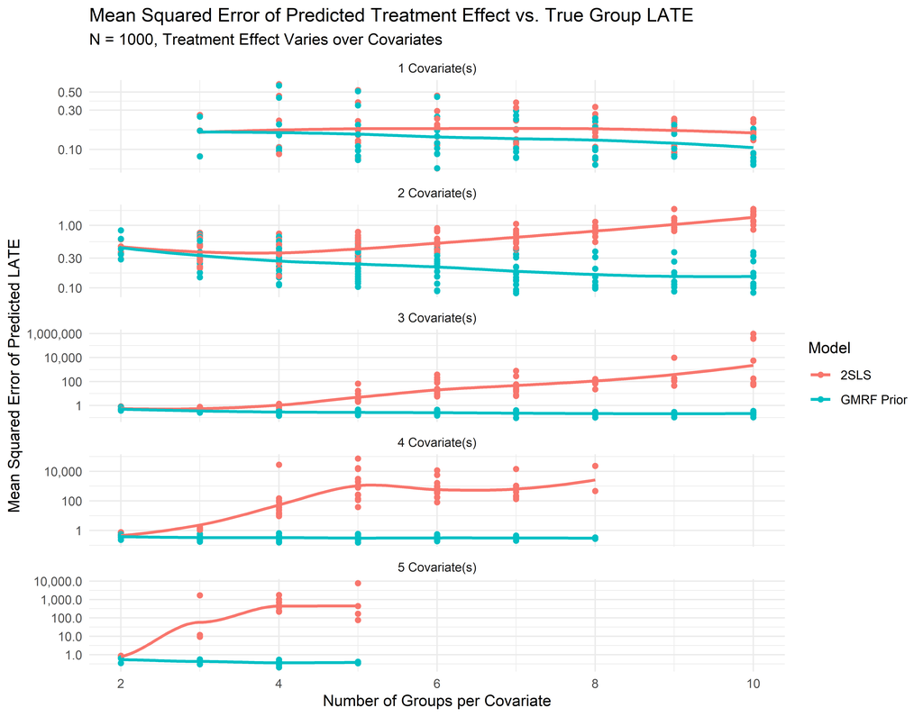

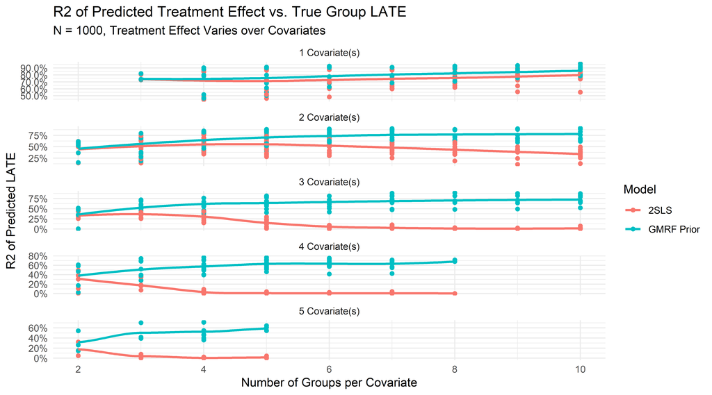

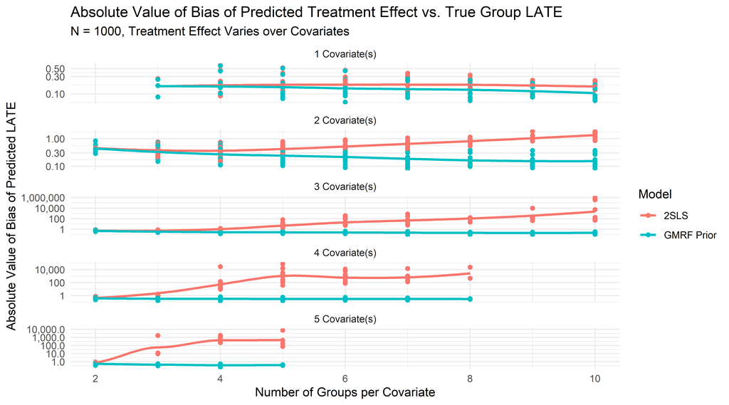

What immediately jumps out is how quickly OLS deteriorates in high dimensional settings! This should not be shocking at all, since the number of groups in the case of 5 covariates quickly exceeds the number of observations. Indeed, in many cases traditional OLS cannot even identify a treatment effect.

To better understand the performance of the GMRF model, I plot the mean square error and R2 of the point predictions, omitting the regular two-stage-least-squares, which degenerates too quickly to see.

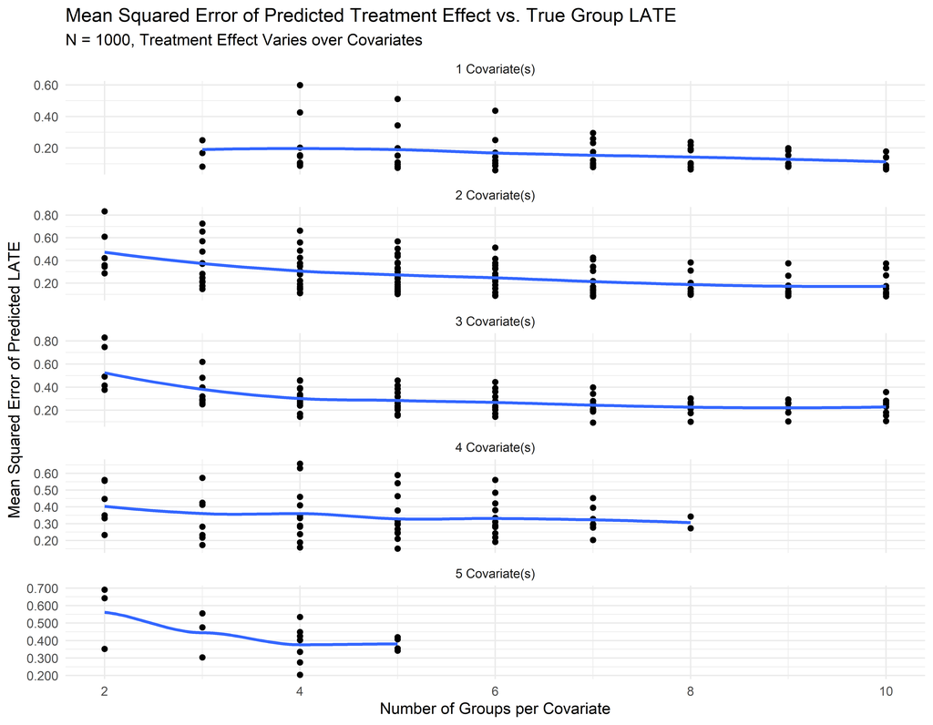

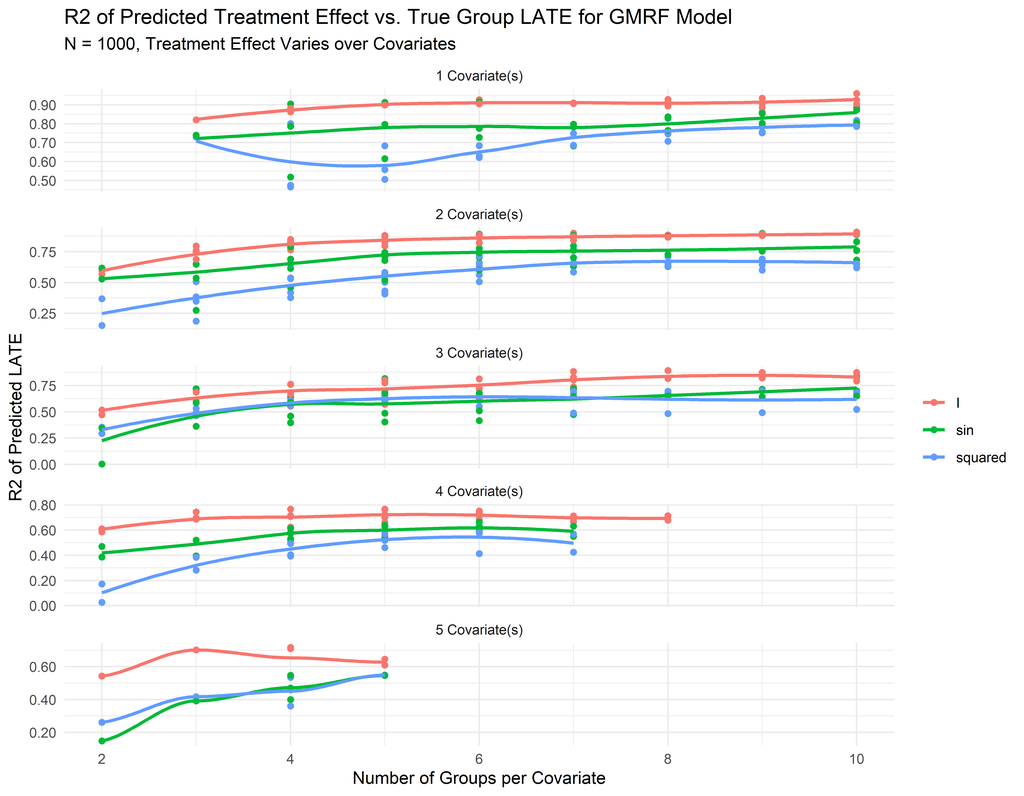

Graphs I need to format still :

### 6 Groups, 1 dimension, tau = x^2

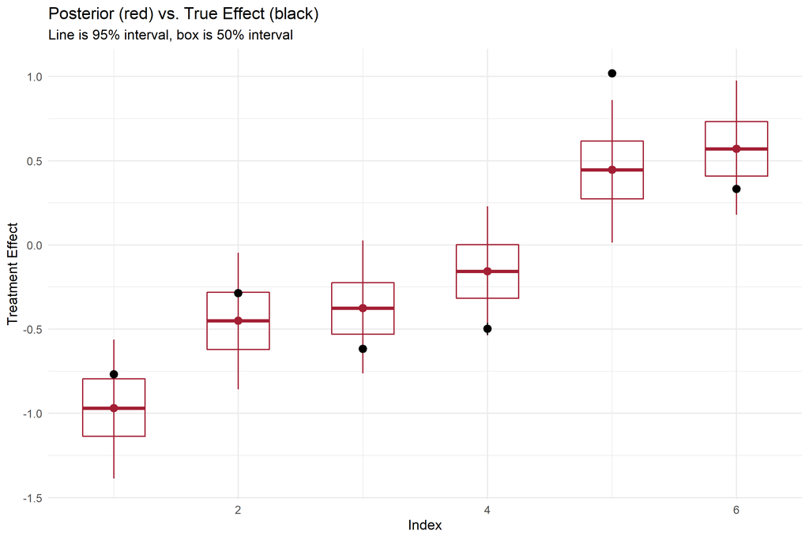

### 6 Groups, 1 dimension, tau = x^2, 2sls point predictions

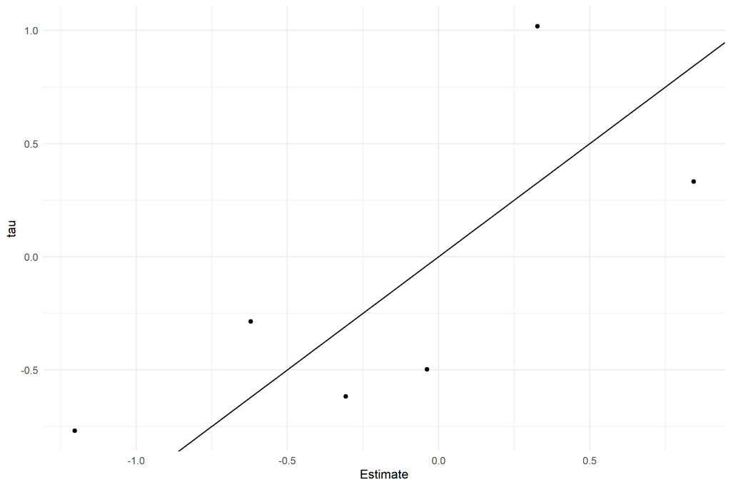

### 6 Groups, 1 dimension, tau = x^2, GMRF point predictions

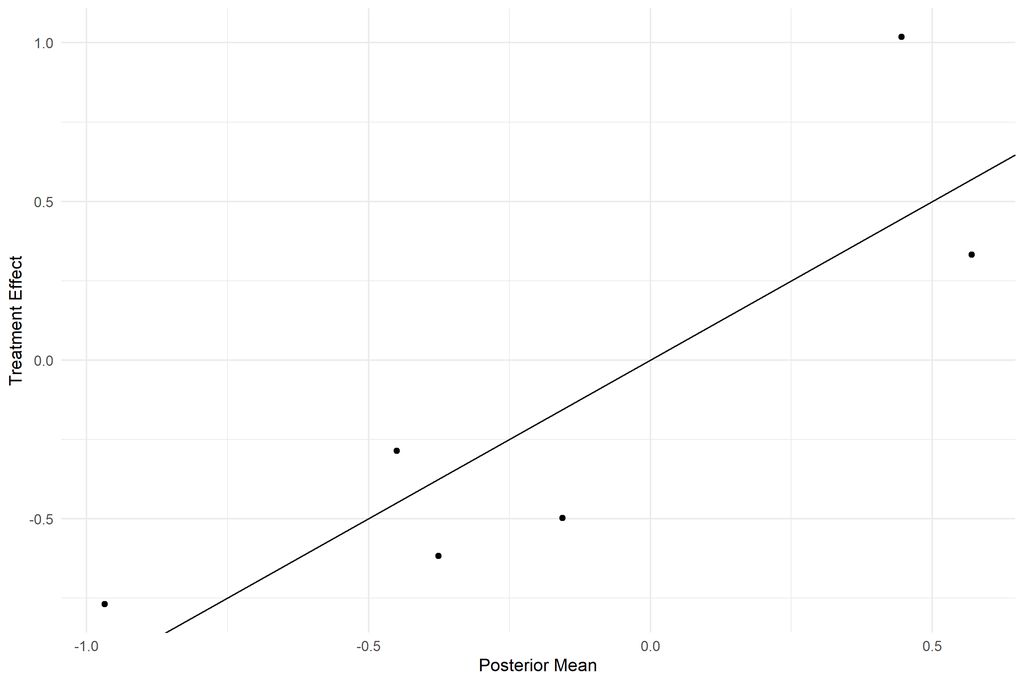

### 6 Groups, 3 dimension, tau = x^2

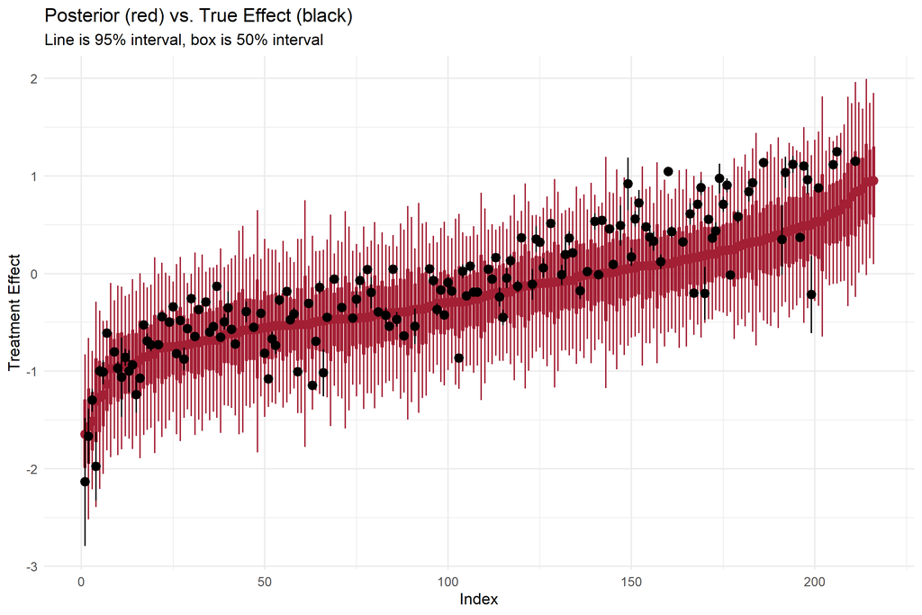

### 6 Groups, 3 dimension, tau = x^2, 2sls point predictions

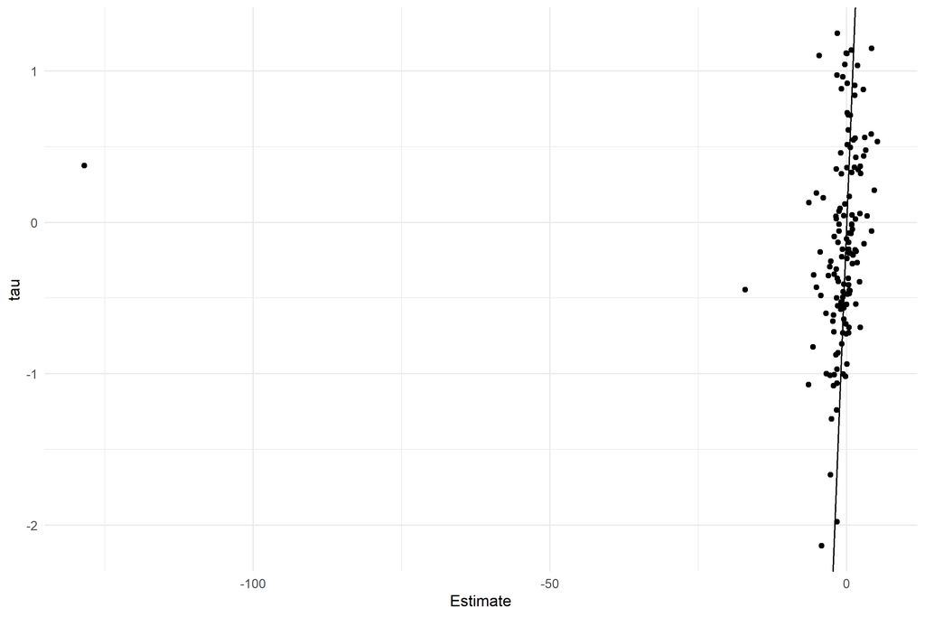

### 6 Groups, 3 dimension, tau = x^2, GMRF point predictions

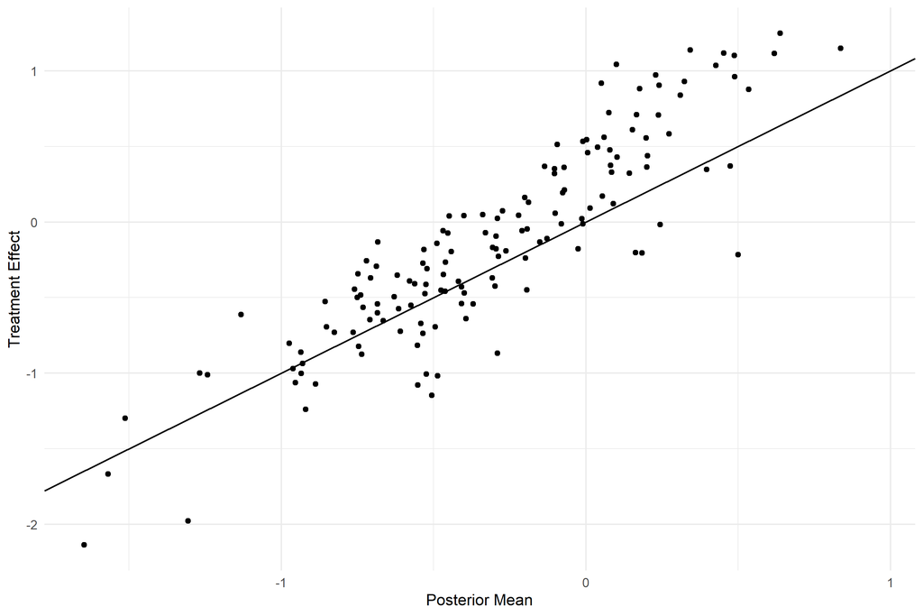

# Empirical Example: OHIE Experiment

- I have the model ready to roll
- Unfortunately, my computer is not big enough to estimate it (13k observations, 38k parameters…)
- Gonna borrow some server time when I get a chance
- Still, kind of amazing that 8 gb of ram is able to fit those models in like *max* 30 min

# Extrapolating to new populations

Given our new knowledge of the treatment effect in that cell, we can make project this local average treatment effect onto the new population by taking a weighted average of the cell-wise LATE estimates, where the weights are determined by the new population. In the survey literature this is known as *regression and post-stratification*, a model that is used to address non-representative responses in surveys, and (for instance) combine polls across states and forecast how a new state will respond (given state-level demographic information).

# Optimal Policy

I have stuff on this but I’m shy and not ready to share. If you got this far I really appreciate it.